# Lab Exercises Week 2 Tidying data

Di Cook

3/6/2018

This is the list of lab exercises from Tuesday’s class. Work your way through them, show your neighbour to check if you have them correct, and then to a tutor. Nothing to turn in today though.

```r
library(tidyverse)
```

## Lab exercise 1

[41% Of Fliers Think You’re Rude If You Recline Your Seat](http://fivethirtyeight.com/datalab/airplane-etiquette-recline-seat/). In the following table, V1 is a response to the question “Is it rude to recline your seat on a plane?”, and V2 is the response to the question “Do you ever recline your seat when you fly?”. The data is in the form of a contingency table.

```r
fly_tbl <- read_csv("data/fly_tbl.csv")
fly_tbl
```

```
## # A tibble: 3 x 6
##   V1         `V2:Always` `V2:Usually` `V2:About half th… `V2:Once in a wh…
##   <chr>            <int>        <int>              <int>             <int>
## 1 No, not r…         124          145                 82               116
## 2 Yes, some…           9           27                 35               129
## 3 Yes, very…           3            3                 NA                11
## # ... with 1 more variable: `V2:Never` <int>
```

1. What are the variables and observations in this data?
2. Put the data in tidy long form (using the names `V2` as the key variable, and `count` as the value).

You can get the data from the [course web site.](http://dmac.netlify.com)

## Lab exercise 2

Your job is to tidy the TB incidence data.

- Write down the steps that will be needed go from raw data to tidy
- Write the code piece by piece

You can get the data from the [course web site.](http://dmac.netlify.com)

## Lab exercise 3

For the data set, `rates.csv`,

```r
rates <- read_csv("data/rates.csv")
head(rates)
```

```
## # A tibble: 6 x 169
##   date         AED   AFN   ALL   AMD   ANG   AOA   ARS   AUD   AWG   AZN
##   <date>     <dbl> <dbl> <dbl> <dbl> <dbl> <dbl> <dbl> <dbl> <dbl> <dbl>
## 1 2017-06-20  3.67  68.1   119   481  1.78   166  16.1  1.32  1.80  1.70
## 2 2017-06-21  3.67  68.1   119   480  1.78   166  16.2  1.32  1.79  1.70
## 3 2017-06-22  3.67  68.1   119   481  1.78   166  16.1  1.33  1.79  1.70
## 4 2017-06-23  3.67  68.1   118   479  1.78   166  16.2  1.32  1.80  1.70
## 5 2017-06-24  3.67  68.1   118   479  1.78   166  16.2  1.32  1.80  1.70
## 6 2017-06-25  3.67  67.9   118   479  1.78   166  16.1  1.32  1.80  1.70
## # ... with 158 more variables: BAM <dbl>, BBD <int>, BDT <dbl>, BGN <dbl>,
## #   BHD <dbl>, BIF <dbl>, BMD <int>, BND <dbl>, BOB <dbl>, BRL <dbl>,
## #   BSD <int>, BTC <dbl>, BTN <dbl>, BWP <dbl>, BYN <dbl>, BZD <dbl>,
## #   CAD <dbl>, CDF <dbl>, CHF <dbl>, CLF <dbl>, CLP <dbl>, CNH <dbl>,
## #   CNY <dbl>, COP <dbl>, CRC <dbl>, CUC <int>, CUP <dbl>, CVE <dbl>,
## #   CZK <dbl>, DJF <dbl>, DKK <dbl>, DOP <dbl>, DZD <dbl>, EGP <dbl>,
## #   ERN <dbl>, ETB <dbl>, EUR <dbl>, FJD <dbl>, FKP <dbl>, GBP <dbl>,
## #   GEL <dbl>, GGP <dbl>, GHS <dbl>, GIP <dbl>, GMD <dbl>, GNF <dbl>,
## #   GTQ <dbl>, GYD <dbl>, HKD <dbl>, HNL <dbl>, HRK <dbl>, HTG <dbl>,
## #   HUF <dbl>, IDR <dbl>, ILS <dbl>, IMP <dbl>, INR <dbl>, IQD <dbl>,
## #   IRR <dbl>, ISK <dbl>, JEP <dbl>, JMD <dbl>, JOD <dbl>, JPY <dbl>,
## #   KES <dbl>, KGS <dbl>, KHR <dbl>, KMF <dbl>, KPW <dbl>, KRW <dbl>,
## #   KWD <dbl>, KYD <dbl>, KZT <dbl>, LAK <dbl>, LBP <dbl>, LKR <dbl>,
## #   LRD <dbl>, LSL <dbl>, LYD <dbl>, MAD <dbl>, MDL <dbl>, MGA <dbl>,
## #   MKD <dbl>, MMK <dbl>, MNT <dbl>, MOP <dbl>, MRO <dbl>, MUR <dbl>,
## #   MVR <dbl>, MWK <dbl>, MXN <dbl>, MYR <dbl>, MZN <dbl>, NAD <dbl>,
## #   NGN <dbl>, NIO <dbl>, NOK <dbl>, NPR <dbl>, NZD <dbl>, OMR <dbl>, …
```

1. What are the variables and observations?
2. Make a time series (line plot) of the Australian dollar cross rate with the USA. What day was the best day to exchange USD into AUD during this period?
3. Focusing on the five currencies, AUD, GBP, JPY, CNY, CAD, make it into tidy long form.
4. Make line plots of the currencies, like the plot below, and describe the similarities and differences between the currencies.

You can get the data from rates.csv

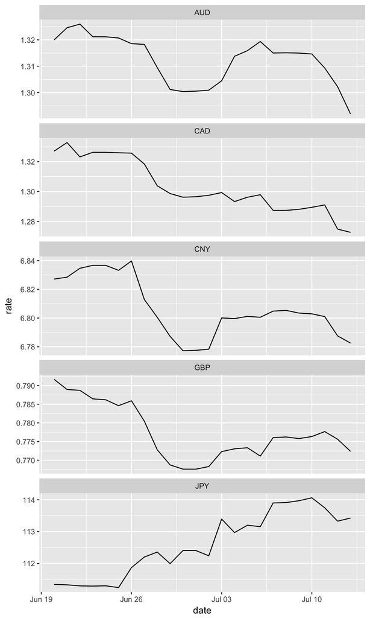

You can get the data from the [course web site.](http://dmac.netlify.com)